# Response to Reviewer 2: convergence of SPD with external human-impact proxies

## Reviewer comment: SPD biases

> **Response.** We agree that an archaeological summed probability distribution (SPD) is an observation-process-sensitive proxy rather than a census. We therefore added an independent convergence analysis against two gridded reconstructions: the KK10 fraction of land under anthropogenic use and HYDE 3.2 population. We used the same record-centred 250 km radius with a 500 km fallback as in the main SPD analysis, area-weighted KK10 fractions and HYDE population summed over cells whose centres fell within each buffer, and the common 8–2 ka BP interval. Following Gordon et al. (2025), observations were assigned to deciles defined by square-root SPD; we compared decile medians and empirical 95% ranges and calculated Kendall rank correlations. The matched analysis included 1181 pollen-record locations and 13 500-year ages. The overall SPD correlation was 0.87 (cluster-bootstrap 95% interval 0.64 to 0.91) for KK10 and 0.69 (cluster-bootstrap 95% interval 0.56 to 0.78) for HYDE. Regional estimates were reported only where at least eight matched bins each contained five datasets and three ages. We also tested first differences, 5 and 20 bins, strict 250 and 500 km supports, and point extraction. Level correlations remained positive with 5 or 20 bins, strict 250 or 500 km radii, and point extraction. In contrast, first-difference correlations were only 0.07 for both proxies, indicating that convergence chiefly reflects broad gradients rather than short-term co-change. These comparisons test convergence among imperfect proxies; they do not establish that SPD is unbiased or that any reconstruction is ground truth.

> **Changes in the revised article.** The Methods now define the external products, units, spatial aggregation, temporal alignment, transformations, coverage rules, and cluster bootstrap. A new supplementary figure reports overall and regional convergence, and a supplementary table provides the matched-bin values, Kendall correlations, sensitivity analyses, and source provenance needed to reproduce every estimate.

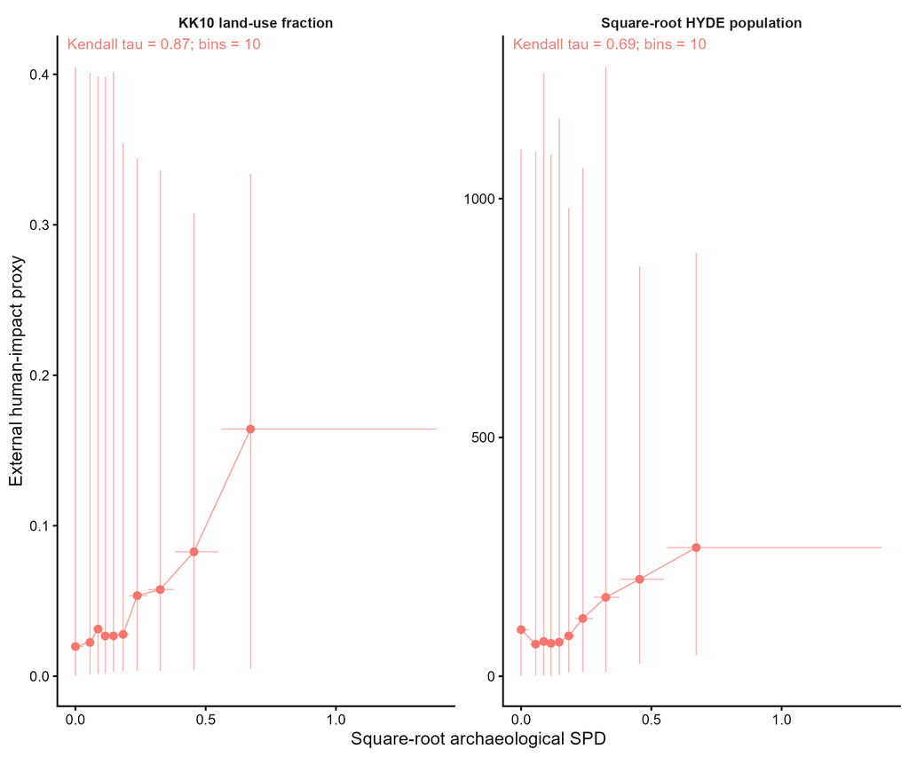

**Supplementary figure: overall proxy convergence.** Points are medians in SPD-defined deciles; horizontal and vertical bars are empirical 95% ranges. The displayed Kendall correlations use decile medians, with uncertainty from resampling complete pollen-record histories.

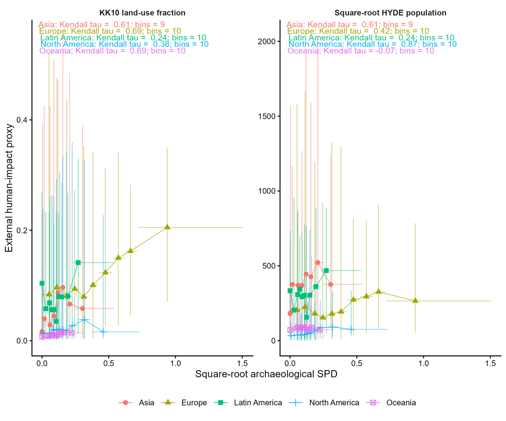

**Supplementary figure: regional proxy convergence.** The analysis and axes match the overall comparison. Estimates that do not meet the prespecified matched-bin, dataset, and age thresholds are labelled as insufficient coverage.

## Recomputable correlation table

| scope_type | scope | comparison_proxy | matched_bins | minimum_bin_datasets | minimum_bin_ages | eligible | kendall_tau | tau_bootstrap_025 | tau_bootstrap_975 |
| --- | --- | --- | --- | --- | --- | --- | --- | --- | --- |
| overall | Overall | hyde | 10 | 338 | 13 | TRUE | 0.69 | 0.56 | 0.78 |
| overall | Overall | kk10 | 10 | 338 | 13 | TRUE | 0.87 | 0.64 | 0.91 |
| region | Asia | hyde | 9 | 22 | 6 | TRUE | 0.61 | 0.11 | 0.86 |
| region | Asia | kk10 | 9 | 22 | 6 | TRUE | 0.61 | 0.28 | 0.86 |
| region | Europe | hyde | 10 | 186 | 11 | TRUE | 0.42 | 0.29 | 0.60 |
| region | Europe | kk10 | 10 | 186 | 11 | TRUE | 0.69 | 0.51 | 0.91 |
| region | Latin America | hyde | 10 | 33 | 8 | TRUE | 0.24 | -0.16 | 0.69 |
| region | Latin America | kk10 | 10 | 33 | 8 | TRUE | 0.24 | -0.16 | 0.51 |
| region | North America | hyde | 10 | 167 | 13 | TRUE | 0.87 | 0.78 | 0.96 |
| region | North America | kk10 | 10 | 167 | 13 | TRUE | 0.38 | 0.16 | 0.73 |
| region | Oceania | hyde | 10 | 17 | 5 | TRUE | -0.07 | -0.51 | 0.34 |
| region | Oceania | kk10 | 10 | 17 | 5 | TRUE | 0.69 | 0.56 | 0.91 |